# midterm

jsg answers

Last compiled on 26 May, 2022 09:00

# Instructions! Read this first.

The exam is open note, open course website, open class-related code repositories (mine and those you produced in class). However, you may not get external help ( from other students, directed internet searches, etc.). Please update the statement below to acknowledge these instructions (and that you can use git).

I, INSERT YOUR NAME HERE, promise to not seek external help on the exam. I understand any academic issues will result in a D or F on the exam or in the class and be reported to the Dean of Students.

Good luck!

COVID-19 vaccines are a key part of the country’s response to the pandemic, but they only work if people take them. Real data from:  
* https://covid.cdc.gov/covid-data-tracker/#vaccinations_vacc-people-onedose-pop-5yr * https://www2.census.gov/geo/pdfs/maps-data/maps/reference/us_regdiv.pdf * https://www.census.gov/library/stories/2021/04/how-do-covid-19-vaccination-and-vaccine-hesitancy-rates-vary-over-time.html

Note some questions are based on pretend surveys, etc, for teaching purposes.

# #1

1. The first national survey of vaccine hesitancy carried out in January 2021 (https://www.census.gov/library/stories/2021/04/how-do-covid-19-vaccination-and-vaccine-hesitancy-rates-vary-over-time.html) by the US Census Bureau showed 21.6% of the population was hesitant about getting the vaccine. A random sample of 2500 people in March 2022 shows that 548 are still hesitant about the vaccine. Is there evidence that vaccine hesitancy has changed over time?

Investigate the question. Make sure you include

- null hypothesis
  - *H<sub>0</sub>: vaccine hesitancy rate has not changed over time/ proportion hesitant about vaccines is .216*
- alternative hypothesis
  - *H<sub>A</sub>: vaccine hesitancy rate has changed over time/ proportion hesitant about vaccines is not .216*
- explanation for test you will use
  - *I will use a binomial test to compare the calculated success rate to a a given value.*
- results from statistical test

```r
binom.test(548,2500, .216)
```

```
##
##  Exact binomial test
##
## data:  548 and 2500
## number of successes = 548, number of trials = 2500, p-value = 0.6974
## alternative hypothesis: true probability of success is not equal to 0.216
## 95 percent confidence interval:
##  0.2031194 0.2359410
## sample estimates:
## probability of success
##                 0.2192
```

- clear explanation of how results relate to your stated hypotheses
  - *I found a p-value of .6974, so I **fail** to reject the null hypothesis.*

# #2

2. What is the confidence interval for proportion of people who are vaccine hesitant? Calculate it and state what a confidence interval means.

```r
library(binom)
binom.confint(548,2500)
```

```
##           method   x    n      mean     lower     upper
## 1  agresti-coull 548 2500 0.2192000 0.2034149 0.2358467
## 2     asymptotic 548 2500 0.2192000 0.2029831 0.2354169
## 3          bayes 548 2500 0.2193123 0.2031669 0.2355836
## 4        cloglog 548 2500 0.2192000 0.2031957 0.2356135
## 5          exact 548 2500 0.2192000 0.2031194 0.2359410
## 6          logit 548 2500 0.2192000 0.2034149 0.2358474
## 7         probit 548 2500 0.2192000 0.2033310 0.2357583
## 8        profile 548 2500 0.2192000 0.2032756 0.2356995
## 9            lrt 548 2500 0.2192000 0.2032778 0.2357173
## 10     prop.test 548 2500 0.2192000 0.2032262 0.2360460
## 11        wilson 548 2500 0.2192000 0.2034206 0.2358410
```

*The 95% confidence interval is .203-.235 using the Agresti-Coull method. A 95% confidence interval means if we sampled the population many times and constructed confidence intervals for each sample, 95% of the time the interval would contain the true population parameter.*

# #3

3. Note the signal in the data was 0.2192. This is not equal to .216. Explain why this simple fact is or isn’t enough to use for a comparision. Make sure you use the term sampling error.
- *Since we are sampling the population to produce a statistic (a proportion in this case), we know that every time we sample we are likely to find a different outcome due to sampling error. Although large sample sizes help this, they do not remove it. Given this we need to compare the signal we found in our data to the distribution of signals we would expect from similarly-sized samples if the null was true.*

# making data for # 4

```r
regions <- read.csv("https://docs.google.com/spreadsheets/d/e/2PACX-1vSHjDv2eSCOtuux9E6JIoEx2F4cOyU6jX6mXUr_FQDtTjpQxroh-IP_3D1z_qcSDr-9lQRQG_CRMZXY/pub?gid=0&single=true&output=csv",
                    stringsAsFactors = T)
rates <- read.csv("https://docs.google.com/spreadsheets/d/e/2PACX-1vT6WmtWdZSUo--2i2nMCWUIMx6BjdJJHKH42oJBzdIZFlAxLH1XztcMI8na-4QKU8ySMHf2-41JwR1y/pub?gid=418071752&single=true&output=csv",
                   stringsAsFactors =T)
```

merge

```r
names(rates)[names(rates) == "State.Territory.Federal.Entity"] = "State"
covid_proportion <- merge(rates, regions, all.x = F, all.y = T)
covid_proportion <- covid_proportion[,c("State", "Percent.of.18..Pop.Fully.Vaccinated.by.State.of.Residence")]
#change to per 100k to remove proportion and help students
covid_proportion <- na.omit(covid_proportion)
covid_proportion$Percent.of.18..Pop.Fully.Vaccinated.by.State.of.Residence <-
  as.numeric(covid_proportion$Percent.of.18..Pop.Fully.Vaccinated.by.State.of.Residence)
covid_proportion$Adults_vaccinated_per_1000 <- covid_proportion$Percent.of.18..Pop.Fully.Vaccinated.by.State.of.Residence*10
write.csv(covid_proportion[,c(1,3)], "covid_proportion.csv", row.names = F)
```

# #4

4. Nationally 443 adults per 1000 are vaccinated against the flu. Data on the number of adults per 1000 vaccinated against COVID (as of 3/2022) in each state is available @

```r
covid <- read.csv("https://docs.google.com/spreadsheets/d/e/2PACX-1vQvZOcUlQy3dV3tqS65mwA2gUAI7a-bPW_AIdZX2I0vWWIjVwasoJ9QjtfR53MkxmSoyae3UVL9IFHS/pub?gid=1461643787&single=true&output=csv",
                             stringsAsFactors = T)
```

in the **Adults_vaccinated_per_1000** column. Is there evidence the number of adults vaccinated against COVID differs from that of those vaccinated against flu?

Investigate the question. Make sure you include

- null hypothesis
  - *H<sub>0</sub>: the number of people per 1000 vaccinated against COVID does not differ from the number that are vaccinated against flu (443)*
- alternative hypothesis
  - *H<sub>0</sub>: the number of people per 1000 vaccinated against COVID does differ from the number that are vaccinated against flu (443).*
- explanation for test you will use
  - *I will use a t-test since we are given multiple samples to compare to a given value. I assume normality given the large sample size.*
- results from statistical test

```r
t.test(covid$Adults_vaccinated_per_1000, mu = 443)
```

```
##
##  One Sample t-test
##
## data:  covid$Adults_vaccinated_per_1000
## t = -8.6527, df = 49, p-value = 1.953e-11
## alternative hypothesis: true mean is not equal to 443
## 95 percent confidence interval:
##  220.9488 304.6512
## sample estimates:
## mean of x
##     262.8
```

- clear explanation of how results relate to your stated hypotheses
  - *A t-test returned t<sub>49</sub>= -8.6527, p <.001, so reject the null hypothesis.*

# #5

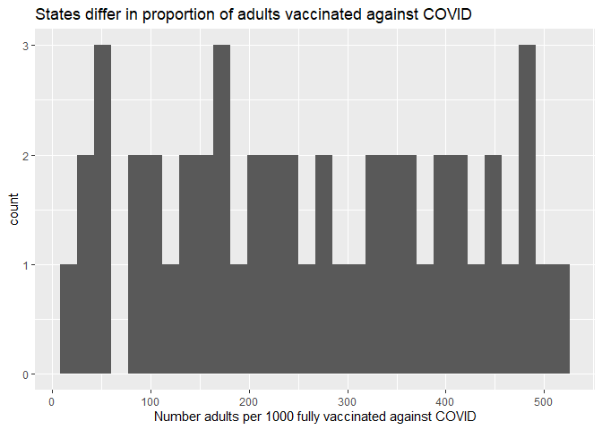

```r
library(ggplot2)
ggplot(covid, aes(x=Adults_vaccinated_per_1000)) +
  geom_histogram()+
  xlab("Number adults per 1000 fully vaccinated against COVID")+
  ggtitle("States differ in proportion of adults vaccinated against COVID")
```

- Using boxplots. Another example (not something you’ve seen…)

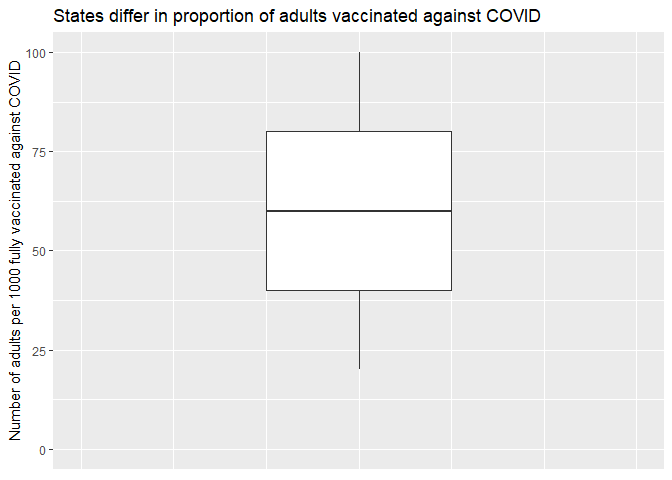

```r
ggplot(covid, aes(y=Adults_vaccinated_per_1000)) +
  geom_boxplot(width = 1)+
  xlim(-1.5,1.5)+ ylim(0,100)+
  ylab("Number of adults per 1000 fully vaccinated against COVID")+
  ggtitle("States differ in proportion of adults vaccinated against COVID")+
  theme(axis.title.x=element_blank(),
        axis.text.x=element_blank(),
        axis.ticks.x=element_blank())
```

- using confidence intervals

```r
library(Rmisc)
```

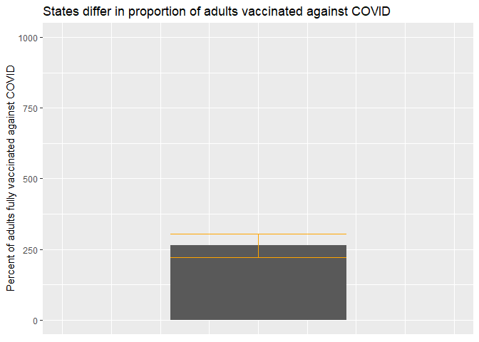

```r
proportion_summary <- summarySE(covid,
                                measurevar = "Adults_vaccinated_per_1000", na.rm = T)
ggplot(proportion_summary, aes( y=Adults_vaccinated_per_1000))+
  geom_col(aes(x=1)) +
  ylim(0,1000)+
  xlim(0,2)+
  ylab("Percent of adults fully vaccinated against COVID")+
  ggtitle("States differ in proportion of adults vaccinated against COVID")+
  geom_errorbar(aes(ymin=Adults_vaccinated_per_1000-ci, ymax=Adults_vaccinated_per_1000+ci, x = 1), color =
                  "orange")+
  theme(axis.title.x=element_blank(),
        axis.text.x=element_blank(),
        axis.ticks.x=element_blank())
```

- using bar charts

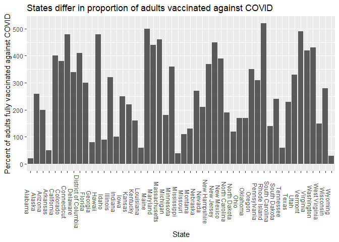

```r
ggplot(covid, aes(y=Adults_vaccinated_per_1000,
                             x=State)) +
  geom_col()+
  ylab("Percent of adults fully vaccinated against COVID")+
  ggtitle("States differ in proportion of adults vaccinated against COVID")+
  theme(axis.text.x=element_text(angle = -90))
```

or

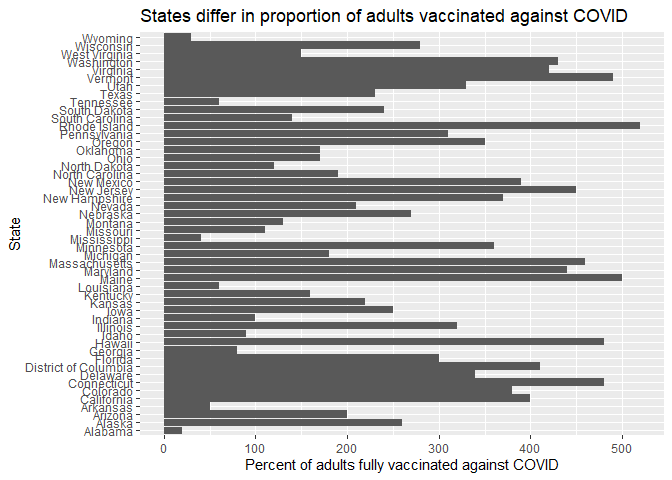

```r
ggplot(covid, aes(x=Adults_vaccinated_per_1000,
                             y=State)) +
  geom_col()+
  xlab("Percent of adults fully vaccinated against COVID")+
  ggtitle("States differ in proportion of adults vaccinated against COVID")
```

or with code from lecture

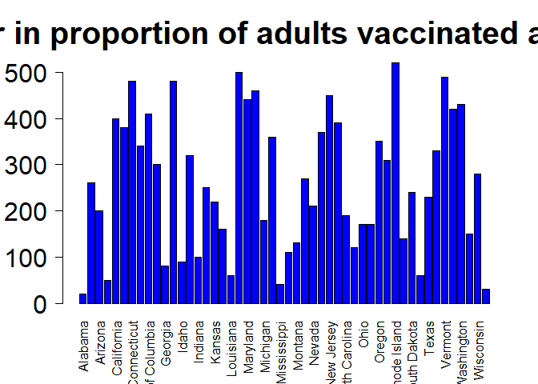

```r
label_size <- 2
title_size <- 2.5
par(las=2)
barplot(covid$Adults_vaccinated_per_1000,
        names.arg = covid$State,
        cex.lab=label_size, cex.axis=label_size,
     cex.main=title_size, cex.sub=label_size, col = "blue", main = "States differ in proportion of adults vaccinated against COVID")
```

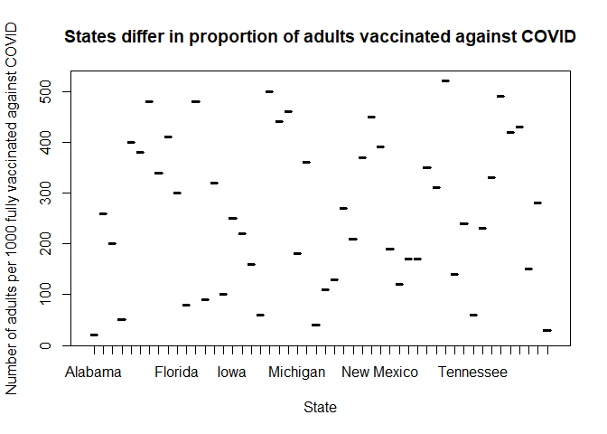

```r
plot(covid$State, covid$Adults_vaccinated_per_1000, type="l",
      ylab="Number of adults per 1000 fully vaccinated against COVID",
  main="States differ in proportion of adults vaccinated against COVID",
       xlab = "State")
```

# #6

6. A new booster is developed to aid against future strains. In testing, 25 individuals who get the new booster develop COVID out of a sample of 1000. This is compared to a group who received the current boosters, where 42 individuals out of 1000 developed COVID. Is there evidence the boosters differ in effectiveness? Investigate the question. Make sure you include
- null hypothesis
  - *H<sub>0</sub>: the proportion of people developing COVID is the same for both boosters*
- alternative hypothesis
  - *H<sub>A</sub>: the proportion of people developing COVID is not the same for both boosters*
- explanation for test you will use
  - *I will attempt to use a $\chi^2$ test to compare proportions for the 2 groups.*
- results from statistical test

```r
#note ether way works
chisq.test(matrix(c(25,1000-25, 42, 1000-42), 2, 2, byrow = T))
```

```
##
##  Pearson's Chi-squared test with Yates' continuity correction
##
## data:  matrix(c(25, 1000 - 25, 42, 1000 - 42), 2, 2, byrow = T)
## X-squared = 3.9533, df = 1, p-value = 0.04678
```

```r
chisq.test(matrix(c(25,42,1000-25,  1000-42), 2, 2, byrow = T))
```

```
##
##  Pearson's Chi-squared test with Yates' continuity correction
##
## data:  matrix(c(25, 42, 1000 - 25, 1000 - 42), 2, 2, byrow = T)
## X-squared = 3.9533, df = 1, p-value = 0.04678
```

# #7

7. Explain what the p-value you provided in question 6 means (what is a p-value)? Given what you found, what would you recommend regarding the booster and/or future work?
- *A p-value is the probability you would see the signal you saw or something more extreme if the null hypothesis was true and you repeated the test many times. Given this value, I would note individuals should take the new booster since it is different and appears to be better at preventing infection.*